# Bike Sharing Analysis with Ford GoBike Data

## Introduction

Bay Wheels is a regional public bicycle sharing system in the San Francisco Bay Area, California operated by Motivate in a partnership with the Metropolitan Transportation Commission and the Bay Area Air Quality Management District. The system was originally launched as Bay Area Bike Share in August 2013. At launch, it became the first regional bicycle sharing system deployed on the West Coast of the United States and also the first regional system in the U.S.

### Preliminary Wrangling

The dataset used for this exploratory analysis consists of monthly individual trip data from Jan 2018 to Dec 2018

```python
# import all packages and set plots to be embedded inline
import numpy as np
import pandas as pd
import matplotlib.pyplot as plt
import seaborn as sb
import glob
import os

%matplotlib inline
import warnings
warnings.simplefilter("ignore")
```

### Gathering and Assessing Data

```python
df = pd.read_csv('fordgobike2018.csv')
df.sample(10)
```

|  | duration_sec | start_time | end_time | start_station_id | start_station_name | start_station_latitude | start_station_longitude | end_station_id | end_station_name | end_station_latitude | end_station_longitude | bike_id | user_type | member_birth_year | member_gender | bike_share_for_all_trip |
| --- | --- | --- | --- | --- | --- | --- | --- | --- | --- | --- | --- | --- | --- | --- | --- | --- |
| 1340973 | 143 | 2018-09-11 07:49:24.4680 | 2018-09-11 07:51:47.4980 | 60.0 | 8th St at Ringold St | 37.774520 | -122.409449 | 350.0 | 8th St at Brannan St | 37.771431 | -122.405787 | 3650 | Subscriber | 1986.0 | Female | No |
| 1482558 | 606 | 2018-10-18 09:10:39.3400 | 2018-10-18 09:20:45.6600 | 3.0 | Powell St BART Station (Market St at 4th St) | 37.786375 | -122.404904 | 81.0 | Berry St at 4th St | 37.775880 | -122.393170 | 2891 | Subscriber | 1979.0 | Male | No |
| 297358 | 1728 | 2018-03-06 12:19:36.6280 | 2018-03-06 12:48:25.5780 | 171.0 | Rockridge BART Station | 37.844279 | -122.251900 | 171.0 | Rockridge BART Station | 37.844279 | -122.251900 | 3217 | Customer | 1999.0 | Male | No |
| 1677041 | 964 | 2018-11-09 16:09:56.0060 | 2018-11-09 16:26:00.7170 | 363.0 | Salesforce Transit Center (Natoma St at 2nd St) | 37.787492 | -122.398285 | 345.0 | Hubbell St at 16th St | 37.766474 | -122.398295 | 3148 | Customer | NaN | NaN | No |
| 745364 | 431 | 2018-06-12 18:30:20.3590 | 2018-06-12 18:37:31.7290 | 176.0 | MacArthur BART Station | 37.828410 | -122.266315 | 189.0 | Genoa St at 55th St | 37.839649 | -122.271756 | 886 | Subscriber | 1991.0 | Female | No |
| 482228 | 247 | 2018-05-24 21:27:17.9410 | 2018-05-24 21:31:25.4400 | 109.0 | 17th St at Valencia St | 37.763316 | -122.421904 | 133.0 | Valencia St at 22nd St | 37.755213 | -122.420975 | 2930 | Subscriber | 1989.0 | Male | No |
| 1812018 | 260 | 2018-12-12 08:45:00.6540 | 2018-12-12 08:49:21.1290 | 196.0 | Grand Ave at Perkins St | 37.808894 | -122.256460 | 182.0 | 19th Street BART Station | 37.809013 | -122.268247 | 2437 | Subscriber | 1993.0 | Male | No |
| 395308 | 480 | 2018-04-12 19:53:31.3320 | 2018-04-12 20:01:31.4330 | 15.0 | San Francisco Ferry Building (Harry Bridges Pl... | 37.795392 | -122.394203 | 10.0 | Washington St at Kearny St | 37.795393 | -122.404770 | 3066 | Customer | 1977.0 | Male | No |
| 937973 | 890 | 2018-07-13 18:10:31.7080 | 2018-07-13 18:25:21.9260 | 19.0 | Post St at Kearny St | 37.788975 | -122.403452 | 8.0 | The Embarcadero at Vallejo St | 37.799953 | -122.398525 | 1570 | Subscriber | 1991.0 | Female | No |
| 1582744 | 217 | 2018-10-03 08:16:41.6730 | 2018-10-03 08:20:19.4840 | 287.0 | Almaden Blvd at Balbach St | 37.326730 | -121.889273 | 313.0 | Almaden Blvd at San Fernando St | 37.331415 | -121.893200 | 625 | Subscriber | 1993.0 | Male | No |

```python
df.info()
```

```
<class 'pandas.core.frame.DataFrame'>
RangeIndex: 1863721 entries, 0 to 1863720
Data columns (total 16 columns):
 #   Column                   Dtype
---  ------                   -----
 0   duration_sec             int64
 1   start_time               object
 2   end_time                 object
 3   start_station_id         float64
 4   start_station_name       object
 5   start_station_latitude   float64
 6   start_station_longitude  float64
 7   end_station_id           float64
 8   end_station_name         object
 9   end_station_latitude     float64
 10  end_station_longitude    float64
 11  bike_id                  int64
 12  user_type                object
 13  member_birth_year        float64
 14  member_gender            object
 15  bike_share_for_all_trip  object
dtypes: float64(7), int64(2), object(7)
memory usage: 227.5+ MB
```

```python
df.bike_share_for_all_trip.value_counts()
```

```
No     1701386
Yes     162335
Name: bike_share_for_all_trip, dtype: int64
```

```python
df.member_gender.value_counts()
```

```
Male      1288085
Female     438188
Other       27081
Name: member_gender, dtype: int64
```

```python
df.member_birth_year.value_counts()
```

```
1988.0    102836
1987.0     86554
1989.0     84830
1990.0     81999
1985.0     79126
           ...
1909.0         4
1889.0         3
1906.0         2
1930.0         1
1903.0         1
Name: member_birth_year, Length: 86, dtype: int64
```

```python
df.user_type.value_counts()
```

```
Subscriber    1583554
Customer       280167
Name: user_type, dtype: int64
```

```python
df.bike_id.value_counts()
```

```
3961    1220
4452    1141
3729    1062
3379    1057
3254    1055
        ...
3763       1
3758       1
4612       1
888        1
4085       1
Name: bike_id, Length: 5054, dtype: int64
```

```python
df.end_station_longitude.value_counts()
```

```
-122.395526    50000
-122.394203    44113
-122.395282    42970
-122.403234    39222
-122.400811    35955
               ...
-74.010000         3
-121.830000        2
-93.220000         2
-122.000000        1
-121.990000        1
Name: end_station_longitude, Length: 371, dtype: int64
```

```python
df.start_station_longitude.value_counts()
```

```
-122.394203    38461
-122.395526    37617
-122.395282    35092
-122.417385    34918
-122.393170    33716
               ...
-121.840000        3
-74.010000         3
-93.220000         2
-121.830000        1
-121.990000        1
Name: start_station_longitude, Length: 370, dtype: int64
```

```python
df.duration_sec.value_counts()
```

```
357      2524
371      2522
342      2521
330      2518
370      2513
         ...
13807       1
15854       1
9709        1
54176       1
12784       1
Name: duration_sec, Length: 16709, dtype: int64
```

```python
df.start_station_name.value_counts()
```

```
San Francisco Ferry Building (Harry Bridges Plaza)           38461
San Francisco Caltrain Station 2  (Townsend St at 4th St)    37617
San Francisco Caltrain (Townsend St at 4th St)               35092
Market St at 10th St                                         34918
Berry St at 4th St                                           33716
                                                             ...
William St at 4th St (Temporary Location)                       26
Viva Calle SJ                                                   25
Williams Ave at 3rd St                                          17
Farnam St at Fruitvale Ave                                      14
2nd St at S Park St                                             11
Name: start_station_name, Length: 348, dtype: int64
```

```python
df.end_station_name.value_counts()
```

```
San Francisco Caltrain Station 2  (Townsend St at 4th St)    50000
San Francisco Ferry Building (Harry Bridges Plaza)           44113
San Francisco Caltrain (Townsend St at 4th St)               42970
The Embarcadero at Sansome St                                39222
Montgomery St BART Station (Market St at 2nd St)             35955
                                                             ...
2nd St at S Park St                                             33
Lane St at Van Dyke Ave                                         33
Williams Ave at 3rd St                                          24
Viva Calle SJ                                                   15
Farnam St at Fruitvale Ave                                      12
Name: end_station_name, Length: 348, dtype: int64
```

```python
df.describe()
```

|  | duration_sec | start_station_id | start_station_latitude | start_station_longitude | end_station_id | end_station_latitude | end_station_longitude | bike_id | member_birth_year |
| --- | --- | --- | --- | --- | --- | --- | --- | --- | --- |
| count | 1.863721e+06 | 1.851950e+06 | 1.863721e+06 | 1.863721e+06 | 1.851950e+06 | 1.863721e+06 | 1.863721e+06 | 1.863721e+06 | 1.753003e+06 |
| mean | 8.573026e+02 | 1.196744e+02 | 3.776678e+01 | -1.223492e+02 | 1.181730e+02 | 3.776690e+01 | -1.223487e+02 | 2.296851e+03 | 1.983088e+03 |
| std | 2.370379e+03 | 1.003976e+02 | 1.057689e-01 | 1.654634e-01 | 1.004403e+02 | 1.056483e-01 | 1.650597e-01 | 1.287733e+03 | 1.044289e+01 |
| min | 6.100000e+01 | 3.000000e+00 | 3.726331e+01 | -1.224737e+02 | 3.000000e+00 | 3.726331e+01 | -1.224737e+02 | 1.100000e+01 | 1.881000e+03 |
| 25% | 3.500000e+02 | 3.300000e+01 | 3.777106e+01 | -1.224114e+02 | 3.000000e+01 | 3.777106e+01 | -1.224094e+02 | 1.225000e+03 | 1.978000e+03 |
| 50% | 5.560000e+02 | 8.900000e+01 | 3.778107e+01 | -1.223974e+02 | 8.800000e+01 | 3.778127e+01 | -1.223971e+02 | 2.338000e+03 | 1.985000e+03 |
| 75% | 8.720000e+02 | 1.860000e+02 | 3.779625e+01 | -1.222865e+02 | 1.830000e+02 | 3.779728e+01 | -1.222894e+02 | 3.333000e+03 | 1.991000e+03 |
| max | 8.636600e+04 | 3.810000e+02 | 4.551000e+01 | -7.357000e+01 | 3.810000e+02 | 4.551000e+01 | -7.357000e+01 | 6.234000e+03 | 2.000000e+03 |

```python
df.isnull().sum()
```

```
duration_sec                    0
start_time                      0
end_time                        0
start_station_id            11771
start_station_name          11771
start_station_latitude          0
start_station_longitude         0
end_station_id              11771
end_station_name            11771
end_station_latitude            0
end_station_longitude           0
bike_id                         0
user_type                       0
member_birth_year          110718
member_gender              110367
bike_share_for_all_trip         0
dtype: int64
```

```python
df.duplicated().sum()
```

```
0
```

### Quality

- there are number of missing data in these columns start_station_id, start_station_name, end_station_id, end_station_name, member_birth_year, member_gender
- Member birth year column should be int instead of float
- startime and end time should be in datetime format not object
- all id columns should ne in object format

### Clean

#### Define

```python
#Make acopy of the dataset
df_cleaned = df.copy()
```

```python
df_cleaned.start_time = pd.to_datetime(df_cleaned.start_time)
df_cleaned.end_time = pd.to_datetime(df_cleaned.end_time)

df_cleaned.start_station_id = df_cleaned.start_station_id.astype('float')
df_cleaned.end_station_id = df_cleaned.end_station_id.astype('float')
df_cleaned.bike_id = df_cleaned.bike_id.astype('float')
df_cleaned['user_type'] = df_cleaned['user_type'].astype('category')
df_cleaned['member_gender'] = df_cleaned['member_gender'].astype('category')
df_cleaned.info()
```

```
<class 'pandas.core.frame.DataFrame'>
RangeIndex: 1863721 entries, 0 to 1863720
Data columns (total 16 columns):
 #   Column                   Dtype
---  ------                   -----
 0   duration_sec             int64
 1   start_time               datetime64[ns]
 2   end_time                 datetime64[ns]
 3   start_station_id         float64
 4   start_station_name       object
 5   start_station_latitude   float64
 6   start_station_longitude  float64
 7   end_station_id           float64
 8   end_station_name         object
 9   end_station_latitude     float64
 10  end_station_longitude    float64
 11  bike_id                  float64
 12  user_type                category
 13  member_birth_year        float64
 14  member_gender            category
 15  bike_share_for_all_trip  object
dtypes: category(2), datetime64[ns](2), float64(8), int64(1), object(3)
memory usage: 202.6+ MB
```

```python
df_cleaned['start_date'] = df_cleaned.start_time.dt.strftime('%Y-%m-%d')
#Start time in hours per day
df_cleaned['start_hour'] = df_cleaned.start_time.dt.strftime('%H')
#Start time in days per week
df_cleaned['start_day'] = df_cleaned.start_time.dt.strftime('%A')
#Start time in month per year
df_cleaned['start_month'] = df_cleaned.start_time.dt.strftime('%B')
#duration in minutes
df_cleaned['duration_min'] = df_cleaned['duration_sec']/60
```

```python
df_cleaned['member_age'] = 2020 - df_cleaned['member_birth_year']
```

```python
df_cleaned.head()
```

|  | duration_sec | start_time | end_time | start_station_id | start_station_name | start_station_latitude | start_station_longitude | end_station_id | end_station_name | end_station_latitude | ... | user_type | member_birth_year | member_gender | bike_share_for_all_trip | start_date | start_hour | start_day | start_month | duration_min | member_age |
| --- | --- | --- | --- | --- | --- | --- | --- | --- | --- | --- | --- | --- | --- | --- | --- | --- | --- | --- | --- | --- | --- |
| 0 | 75284 | 2018-01-31 22:52:35.239 | 2018-02-01 19:47:19.824 | 120.0 | Mission Dolores Park | 37.761420 | -122.426435 | 285.0 | Webster St at O'Farrell St | 37.783521 | ... | Subscriber | 1986.0 | Male | No | 2018-01-31 | 22 | Wednesday | January | 1254.733333 | 34.0 |
| 1 | 85422 | 2018-01-31 16:13:34.351 | 2018-02-01 15:57:17.310 | 15.0 | San Francisco Ferry Building (Harry Bridges Pl... | 37.795392 | -122.394203 | 15.0 | San Francisco Ferry Building (Harry Bridges Pl... | 37.795392 | ... | Customer | NaN | NaN | No | 2018-01-31 | 16 | Wednesday | January | 1423.700000 | NaN |
| 2 | 71576 | 2018-01-31 14:23:55.889 | 2018-02-01 10:16:52.116 | 304.0 | Jackson St at 5th St | 37.348759 | -121.894798 | 296.0 | 5th St at Virginia St | 37.325998 | ... | Customer | 1996.0 | Male | No | 2018-01-31 | 14 | Wednesday | January | 1192.933333 | 24.0 |
| 3 | 61076 | 2018-01-31 14:53:23.562 | 2018-02-01 07:51:20.500 | 75.0 | Market St at Franklin St | 37.773793 | -122.421239 | 47.0 | 4th St at Harrison St | 37.780955 | ... | Customer | NaN | NaN | No | 2018-01-31 | 14 | Wednesday | January | 1017.933333 | NaN |
| 4 | 39966 | 2018-01-31 19:52:24.667 | 2018-02-01 06:58:31.053 | 74.0 | Laguna St at Hayes St | 37.776435 | -122.426244 | 19.0 | Post St at Kearny St | 37.788975 | ... | Subscriber | 1991.0 | Male | No | 2018-01-31 | 19 | Wednesday | January | 666.100000 | 29.0 |

5 rows × 22 columns

```python
df_cleaned.member_age.mean()
```

```
36.91203780027758
```

```python
df_cleaned.shape
```

```
(1863721, 22)
```

```python
df_cleaned.to_csv('fordgo_master2018_cl.csv', index = False)
```

### What is the structure of your dataset?

- Duration:
  - Start Time
  - End Time
- Station ID (startt & end)
  - start station Name
  - start station Latitude
  - start station Longitude
  - end station id
  - end station Name
  - end station Latitude
  - end station Longitude
- Member info
  - bike id
  - user type
  - member birth year
  - member gender(I added)
  - bike share for all trip

### What is/are the main feature(s) of interest in your dataset?

There is alot like (Start time and end time) to know when there is higher demand on the service, there is also enough nuber of data to determine under what category most customers fall in.

### What features in the dataset do you think will help support your investigation into your feature(s) of interest?

I think I will use start/end time and most of the features about the rider

## Univariate Exploration

> In this section, investigate distributions of individual variables. If you see unusual points or outliers, take a deeper look to clean things up and prepare yourself to look at relationships between variables.

```python
#removing colors to avoid distraction
base_color = sb.color_palette()[0]
```

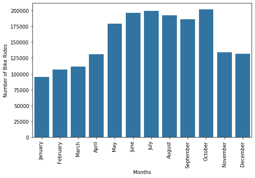

```python
#visualizing number of rides started in each month
plt.rcParams['figure.figsize'] = 8, 5
sb.countplot(data = df_cleaned, x='start_month', color = base_color)
plt.xlabel('Months');
plt.ylabel('Number of Bike Rides');
plt.xticks(rotation =90);
```

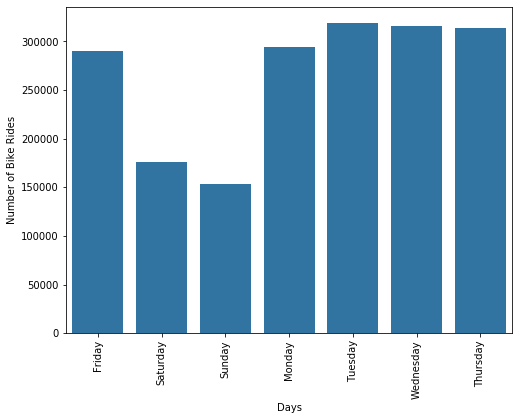

```python
#visualizing number of rides started in each day
days_order = ['Friday', 'Saturday', 'Sunday', 'Monday', 'Tuesday', 'Wednesday', 'Thursday']
plt.rcParams['figure.figsize'] = 8, 6
sb.countplot(data = df_cleaned, x='start_day', color = base_color, order = days_order)
plt.xlabel('Days');
plt.ylabel('Number of Bike Rides');
plt.xticks(rotation =90);
```

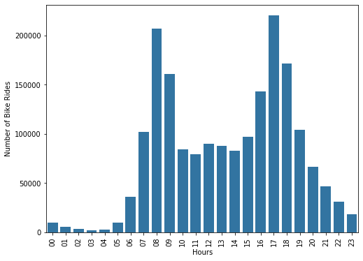

```python
#visualizing number of rides started hour
plt.rcParams['figure.figsize'] = 8, 6
sb.countplot(data = df_cleaned, x='start_hour', color = base_color)
plt.xlabel('Hours');
plt.ylabel('Number of Bike Rides');
plt.xticks(rotation =90);
```

**My observation of the last part is that The trip distribution over day is most active between 8am-9am and 17pm-18pm with a small difference, and also it appears that the majority of rides happened on work day from Monday to Friday maybe most of them use the service for commuting.through 2018, October had the most ride trips compared to the others, but generally it was high usage from May to Septemper.**

> Make sure that, after every plot or related series of plots, that you include a Markdown cell with comments about what you observed, and what you plan on investigating next.

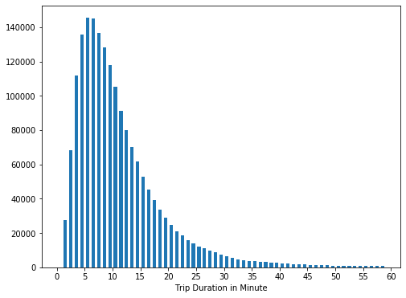

```python
#visualizing duration in minutes
bins = np.arange(0,60, 1)
ticks = np.arange(0, 65, 5)
plt.hist(data=df_cleaned, x='duration_min', bins=bins, rwidth = 0.6);
plt.xticks(ticks);
plt.xlabel('Trip Duration in Minute');
```

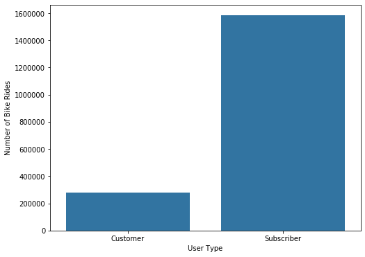

```python
#here i'm observing the difference in user types
sb.countplot(data=df_cleaned, x='user_type', color=base_color);
plt.rcParams['figure.figsize'] = 8, 5
plt.xlabel('User Type');
plt.ylabel('Number of Bike Rides');
```

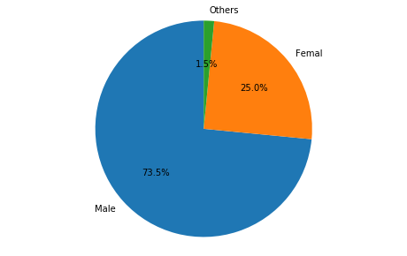

```python
#observing the gender of users using the service

labels = 'Male', 'Femal', 'Others'
sizes = [15, 30, 45, 10]
fig1, ax1 = plt.subplots()
ax1.pie(df_cleaned.member_gender.value_counts(), labels=labels, autopct='%1.1f%%',
         startangle=90)
ax1.axis('equal')  # Equal aspect ratio ensures that pie is drawn as a circle.

plt.show()
```

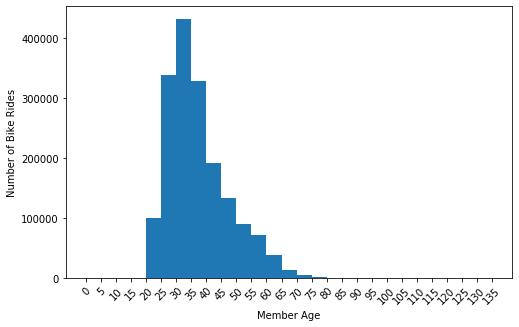

```python
#observing the age of users using the service
bins = np.arange(0, df_cleaned.member_age.max()+1, 5)
plt.hist(data=df_cleaned, x='member_age', bins=bins);
plt.xticks(bins, rotation =45);
plt.rcParams['figure.figsize'] = 8, 5
plt.xlabel('Member Age');
plt.ylabel('Number of Bike Rides');
```

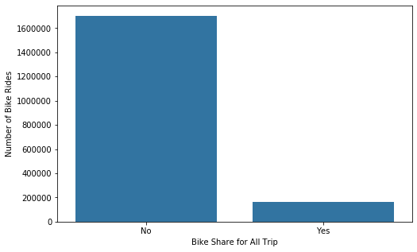

```python
#observing the bike_share_for_all_trip of users using the service
sb.countplot(data=df_cleaned, x='bike_share_for_all_trip', color=base_color);
plt.xlabel('Bike Share for All Trip');
plt.rcParams['figure.figsize'] = 8, 5
plt.xlabel('Bike Share for All Trip');
plt.ylabel('Number of Bike Rides');
```

**After all these plots about members info, I obseerved that Most of users are under subscriber type, the vast majority of them are male gender , and most of the users are abour 35 years old and the majority between 20 and 45.**

### Discuss the distribution(s) of your variable(s) of interest. Were there any unusual points? Did you need to perform any transformations?

After the cleaning part I didn't need to perform much transformation. My observation of the time part is that The trip distribution over day is most active between 8am-9am and 17pm-18pm with a small difference, and also it appears that the majority of rides happened on work day from Monday to Friday maybe most of them use the service for commuting.through 2018, October had the most ride trips compared to the others, but generally it was high usage from May to Septemper. I also observed that Most of users are under subscriber type, the vast majority of them are male gender , and most of the users are abour 35 years old and the majority between 20 and 45.

### Of the features you investigated, were there any unusual distributions? Did you perform any operations on the data to tidy, adjust, or change the form of the data? If so, why did you do this?

I did perform some operation on the data to put the destribution in a way that will benefit my visualization and give me beter understanding of the data.

## Bivariate Exploration

> In this section, investigate relationships between pairs of variables in your data. Make sure the variables that you cover here have been introduced in some fashion in the previous section (univariate exploration).

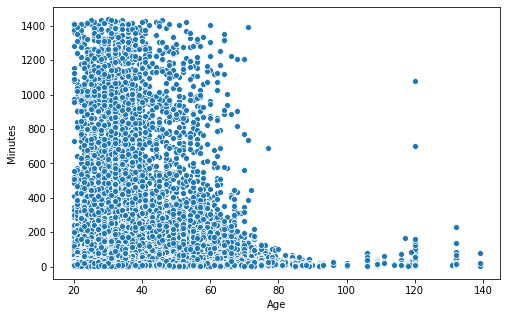

```python
#the duration of trips and ages
sb.scatterplot(data=df_cleaned, x='member_age', y='duration_min');
plt.xlabel('Age');
plt.ylabel('Minutes');
```

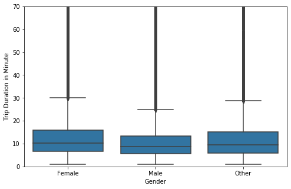

```python
sb.boxplot(data=df_cleaned, x='member_gender', y='duration_min', color=base_color);
plt.xlabel('Gender');
plt.ylabel('Trip Duration in Minute');
plt.ylim(0,70);
```

```
(0, 70)
```

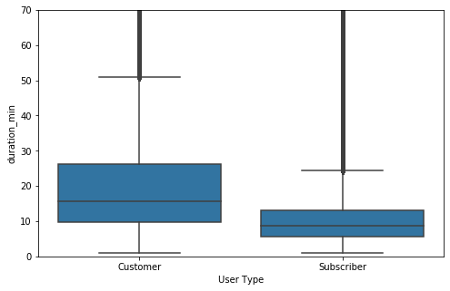

```python
sb.boxplot(data=df_cleaned, x='user_type', y='duration_min', color=base_color);
plt.xlabel('User Type');

plt.ylim(0,70)
```

```
(0, 70)
```

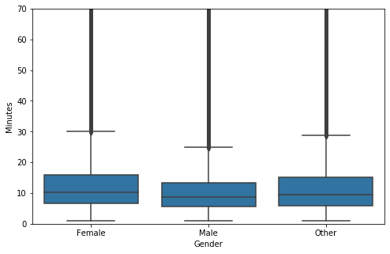

```python
sb.boxplot(data=df_cleaned, x='member_gender', y='duration_min', color=base_color);
plt.xlabel('Gender');
plt.ylabel('Minutes');
plt.ylim(0,70)
```

**From the above observations we indecate that most riders are males and they tend to smaller trips and also the subscriber type of users tend to smaller trips as they have a porpuse or a destination not like the custmers and also the longest trip tends to be for the peaple between ages 20 to 40 years old**

**Here I will start observing use_type and member_gender**

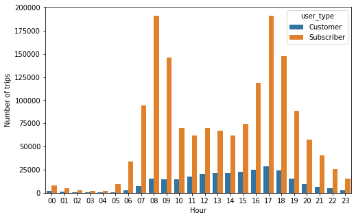

```python
#Comparing number of subscriber to number of custome each hour per day
sb.countplot(data=df_cleaned, x='start_hour', hue='user_type');
plt.xlabel('Hour');
plt.ylabel('Number of trips');
```

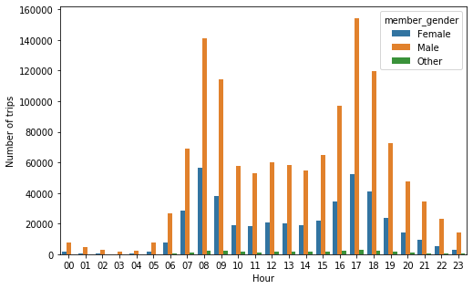

```python
#Compre between number of genders each hour per day
sb.countplot(data=df_cleaned, x='start_hour', hue='member_gender');
plt.xlabel('Hour');
plt.ylabel('Number of trips');
```

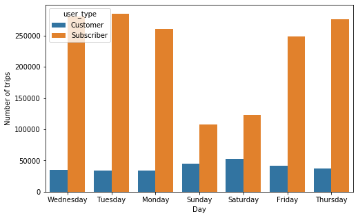

```python
#Comparing number of subscriber to number of custome each day per week
sb.countplot(data=df_cleaned, x='start_day', hue='user_type');
plt.xlabel('Day');
plt.ylabel('Number of trips');
```

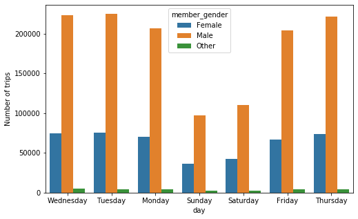

```python
#Compre between number of genders each day per week
sb.countplot(data=df_cleaned, x='start_day', hue='member_gender');
plt.xlabel('day');
plt.ylabel('Number of trips');
```

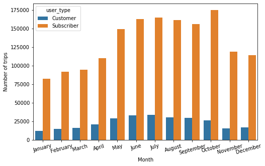

```python
#Comparing number of subscriber to number of custome each month per year
sb.countplot(data=df_cleaned, x='start_month', hue='user_type');
plt.xlabel('Month');
plt.ylabel('Number of trips');
plt.xticks(rotation = 15);
```

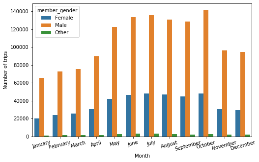

```python
#Compre between number of genders each month per year
sb.countplot(data=df_cleaned, x='start_month', hue='member_gender');
plt.xlabel('Month');
plt.ylabel('Number of trips');
plt.xticks(rotation = 15);
```

**What I notised from my observation is number of subscribers is much more than number of customers and reaches its peak in 8 am and 17 pm probably because it is times of going to work and going home and also in working days the differnce is much high as for the month the diffrence stays very high and become much more in summer month and reaches the peak in october. For genders males are much more in numbers than female and the number reaches the peak at 17pm as for females there number reaches its peak at 8 am.**

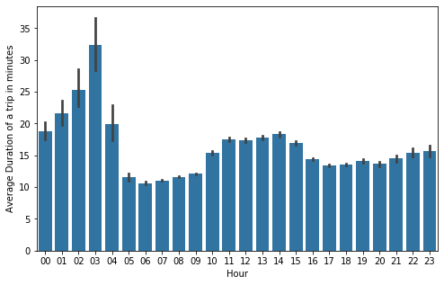

```python
#The average time spent each hour
sb.barplot(data=df_cleaned, x='start_hour', y='duration_min', color=base_color);
plt.xlabel('Hour');
plt.ylabel('Average Duration of a trip in minutes');
```

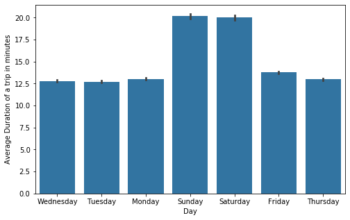

```python
#The average time spent each day
sb.barplot(data=df_cleaned, x='start_day', y='duration_min', color=base_color);
plt.xlabel('Day');
plt.ylabel('Average Duration of a trip in minutes');
```

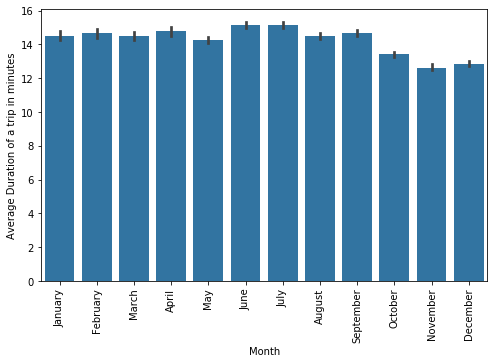

```python
#The average time spent each month
sb.barplot(data=df_cleaned, x='start_month', y='duration_min', color=base_color);
plt.xlabel('Month');
plt.ylabel('Average Duration of a trip in minutes');
plt.xticks(rotation = 90)
```

### Talk about some of the relationships you observed in this part of the investigation. How did the feature(s) of interest vary with other features in the dataset?

What i undrstood from the data is the subscribers are way more than customers and they are usually commuters going to work or home as data shows that work days and work hours are much more than the usuall. the customers can be tourists visitors or citizens who like riding as they tend to be more active in the weekend the summer month and also in the early evenings.

### Did you observe any interesting relationships between the other features (not the main feature(s) of interest)?

the customers are younger than the subscribers therefore they tend to have more trips duration than for subscribers since they ride for fun in weekend and summner months. also whats interesting is that males are much more than femals and the peak hour for males is 17 pm and for females 8 am .

## Multivariate Exploration

> Create plots of three or more variables to investigate your data even further. Make sure that your investigations are justified, and follow from your work in the previous sections.

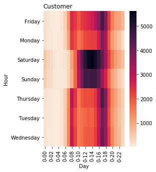

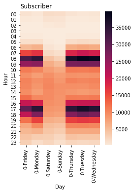

```python
plt.subplot(1, 2, 1)

customer = df_cleaned.query('user_type == "Customer"')
customer = customer.groupby(['start_day', 'start_hour']).size()
customer = customer.reset_index();
customer = customer.pivot('start_day', 'start_hour')
sb.heatmap(customer, cmap='rocket_r');
plt.title('Customer', loc='left')
plt.xlabel('Day')
plt.ylabel('Hour')


plt.show()
plt.subplot(1, 2, 2)
subscriber = df_cleaned.query('user_type == "Subscriber"')
subscriber = subscriber.groupby(['start_hour', 'start_day']).size()
subscriber = subscriber.reset_index();
subscriber = subscriber.pivot('start_hour', 'start_day')
sb.heatmap(subscriber, cmap = 'rocket_r')

plt.title("Subscriber", loc='left')
plt.xlabel('Day')
plt.ylabel('Hour');

plt.show()
```

**The heat map proves my last observations the subscribers are using the servies heavily in the work days from monday to friday and the work hours from 8am to 17 and not using it alot in other times that suggests that they are commuters. as for customers the are using the service heavily from 7am to 18 pm and specially in saterday and sunday. and that suggests that they are tourists or visitor having good time.**

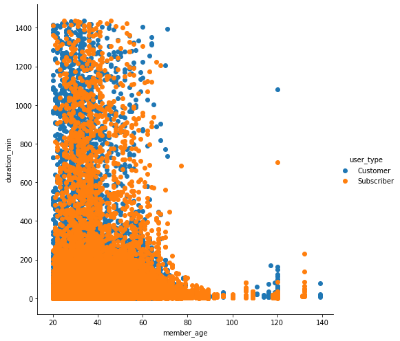

```python
g = sb.FacetGrid(data = df_cleaned, hue = 'user_type', size = 7)
g.map(plt.scatter, 'member_age', 'duration_min')
g.add_legend()
```

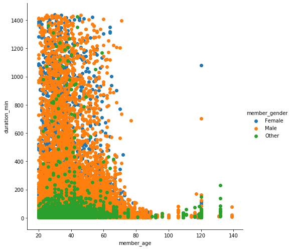

```python
g = sb.FacetGrid(data = df_cleaned, hue = 'member_gender', size = 7)
g.map(plt.scatter, 'member_age', 'duration_min')
g.add_legend()
```

**From this plot we can say that the customer take more time in there trips than the sudscribers both types have increase in trip duration in the age between 20 to 38 and specially for customers as they are not running for there work so there is not much customers older than 38**

### Talk about some of the relationships you observed in this part of the investigation. Were there features that strengthened each other in terms of looking at your feature(s) of interest?

in this part we just demonstrated our previous observations in bivariate exploration as well as univariate exploration but with diffrenet visualizing plots. the diffrence on multivariable plotting is that we used more than two variables to visualize our dataset. the shortness in time for sucbscribers comes for the seriousness of there situation they are going to there work. as for customers the have the time to spend so they take longer trip duration.

### Were there any interesting or surprising interactions between features?

Nothing we didn't discover before may be the relationship between the duration time, the age and the user type was quite noticable as most of customers have more trip duration time than subscribers. and also how the number of user dramaticly dicreases after the age of 40. also more numbers of females spend more time in there trips.

## Conclusion

The idea of renting a bike for either going to work or to have some fun is great and wonderful. It helps to have much clean environment. Most of the riders are males. most of the users are subscriber and commuters there primary usage is for work. Customers are tourists, visitors or citizens who love riding bikes.

> At the end of your report, make sure that you export the notebook as an html file from the `File > Download as... > HTML` menu. Make sure you keep track of where the exported file goes, so you can put it in the same folder as this notebook for project submission. Also, make sure you remove all of the quote-formatted guide notes like this one before you finish your report!